# Monitoreo Nacional de Homicidios

Paula Borrego

MAL, PERO MEJORANDO

> La semana del 2 al 8 de diciembre de 2024, se registraron 480 homicidios, un valor muy cercano al nuevo límite de advertencia positiva (LAP= 477). Es también el valor más bajo de homicidios por semana desde los 476 que se registraron del 12 al 18 de agosto pasado. Recordemos que la semana pasada se completaron 5 semanas por debajo del promedio anterior, que era 533 y recalculamos todos los límites hacia abajo, siendo nuestro nuevo valor central 515 homicidios por semana.

> Cabe insistir en que este valor de 480 es el valor más bajo en las escasas 10 semanas del sexenio de CSP y el segundo más bajo desde que retomamos el Monitoreo Nacional de Homicidios, siendo el más bajo de 476 la semana del 12 al 18 de agosto, correspondiente al sexenio de AMLO. Si alguien me preguntara ¿cómo va el tema de homicidios? Mi respuesta sería: “Mal, pero mejorando”.

HOMICIDIOS POR SEMANA EN MÉXICO

DIAGNÓSTICO: VALOR CERCANO A LA NUEVAADVERTENCIA POSITIVA

Serie por debajo del Promedio

Diagrama C

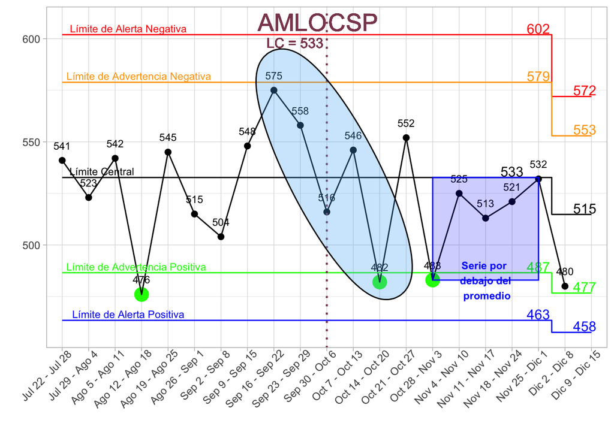

Fuente: http://www.informeseguridad.cns.gob.mx

sabaconsultores.com